# Machine Learning Project (Coursera)

Israel Yahalom

Monday, May 11, 2015

# SYNOPSYS

This document describes Coursera assignment in the field of *Machine Learning Process (MLP)*. Basically the MLP is a 2 stage process: in the first stage the machine (computer) utilizes some algorithms to analyze a given dataset and learn its characteristics. Following a successful learning process, the machine is capable to produce good (enough) predictions that are tested on another but similar dataset.

The data used in this assignment was recorded by several devices (such as Jawbone Up, Nike FuelBand, and/or Fitbit) different types of human physical activities. The 2 datasets, for learning and for predicting, were sourced from http://groupware.les.inf.puc-rio.br/har.

The goal of the assignment is to apply the MLP on 1st dataset and then based on the 2nd dataset to predict the correct type of activity (one of five specific activities).

# THE DATA

## Loading the Data

We start with setting the working directory, cleaning the memory and loading the datasets, one for learning (training) and one for predicting (testing) .

```r
setwd("F:/Data Science Specialization/8 Practical Machine Learning/Project")
rm(list = ls(all = TRUE))
dtrain<- read.csv("pml-training.csv", na.strings=c('NA','','#DIV/0!'))
dtest<- read.csv("pml-testing.csv", na.strings=c('NA','','#DIV/0!'))
```

## Data Observation

```r
dim(dtrain); dim(dtest)
```

```
## [1] 19622   160
```

```
## [1]  20 160
```

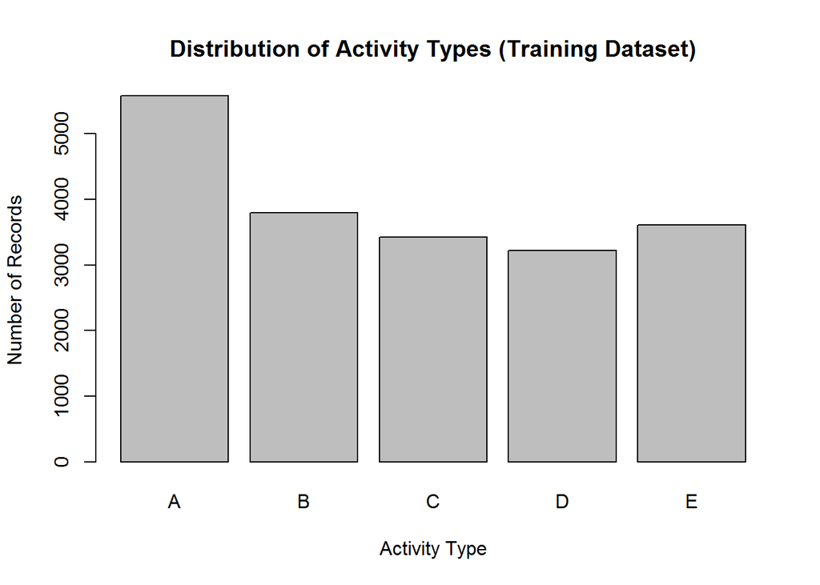

```r
barplot(summary(dtrain$classe), main="Distribution of Activity Types (Training Dataset)", xlab="Activity Type", ylab="Number of Records")
```

## Creating Validation Data Set

Using the ‘caret’ package (with a small fix function to the package), the training data set was divided into two subsets: ttrain=75% of total observations and tvald set = 25% of the observations

```r
library(caret)
#fix for caret package
class2ind <- function(cl)
{
      n <- length(cl)
      cl <- as.factor(cl)
      x <- matrix(0, n, length(levels(cl)) )
      x[(1:n) + n*(unclass(cl)-1)] <- 1
      dimnames(x) <- list(names(cl), levels(cl))
      x
}
set.seed(1111)
inTrain<- createDataPartition(y=dtrain$classe, p=0.75, list=FALSE)
ttrain<- dtrain[inTrain,]
tvalid<- dtrain[-inTrain,]
dim(ttrain); dim(tvalid)
```

```
## [1] 14718   160
```

```
## [1] 4904  160
```

## Prepare For Learning

The aim of this stage is to reduce the number of variables (160 columns) to shorten the time of the learning session.  
The first 7 columns are indices and are not related to any physical activity, so we started with removing them in all 3 datasets.

```r
ttrain<- ttrain[,-c(1:7)]
tvalid<- tvalid[,-c(1:7)]
dtest<-dtest[,-c(1:7)]
```

Now we analyzed the training dataset and searched variables (columns) that contain large quantity of missing values (NAs).

```r
high_na<- sapply(ttrain, function(x) {sum(is.na(x))})
table(high_na)
```

```
## high_na
##     0 14417 14418 14420 14423 14424 14441 14476 14477 14478 14479 14718
##    53    67     2     5     5     2     2     5     2     2     2     6
```

It is clear that 53 variables (columns) has no missing value but the other 100 variables contain large quantity of NA values. We decided to remove every variable that contains more than 95% NA observations

```r
na_var<- names(high_na[high_na>=95/100*dim(ttrain)[1]])
```

We applied this reducing variables strategy to all 3 datasets.

```r
ttrain<- ttrain[, !names(ttrain) %in% na_var]
tvalid<- tvalid[, !names(tvalid) %in% na_var]
dtest<- dtest[, !names(dtest) %in% na_var]
```

This strategy produced datasets with only 53 variables, 52 predictors and 1 result variable

```r
dim (ttrain); dim(tvalid); dim(dtest)
```

```
## [1] 14718    53
```

```
## [1] 4904   53
```

```
## [1] 20 53
```

# LEARNING

## Training

We used the “ttrain” data set, the “Random Forests” method (rf) and the “train”" function in “caret” to consilidate the model.

```r
Model<- train(classe~., data=ttrain, method="rf", tuneGrid = data.frame(mtry = 3))
saveRDS(Model, "Model.RDS")
Model
```

```
## Random Forest
##
## 14718 samples
##    52 predictor
##     5 classes: 'A', 'B', 'C', 'D', 'E'
##
## No pre-processing
## Resampling: Bootstrapped (25 reps)
##
## Summary of sample sizes: 14718, 14718, 14718, 14718, 14718, 14718, ...
##
## Resampling results
##
##   Accuracy   Kappa      Accuracy SD  Kappa SD
##   0.9901704  0.9875615  0.001778645  0.002252429
##
## Tuning parameter 'mtry' was held constant at a value of 3
##
```

## Validating

Initially we tested the prediction quality of the model on the training data set, and displayed the results by the “confusionMatrix” function of “caret” package.

```r
prediction <- predict(Model, ttrain)
confusionMatrix(prediction, ttrain$classe)
```

```
## Confusion Matrix and Statistics
##
##           Reference
## Prediction    A    B    C    D    E
##          A 4184    2    0    0    0
##          B    1 2844    1    0    0
##          C    0    2 2566    7    0
##          D    0    0    0 2405    0
##          E    0    0    0    0 2706
##
## Overall Statistics
##
##                Accuracy : 0.9991
##                  95% CI : (0.9985, 0.9995)
##     No Information Rate : 0.2843
##     P-Value [Acc > NIR] : < 2.2e-16
##
##                   Kappa : 0.9989
##  Mcnemar's Test P-Value : NA
##
## Statistics by Class:
##
##                      Class: A Class: B Class: C Class: D Class: E
## Sensitivity            0.9998   0.9986   0.9996   0.9971   1.0000
## Specificity            0.9998   0.9998   0.9993   1.0000   1.0000
## Pos Pred Value         0.9995   0.9993   0.9965   1.0000   1.0000
## Neg Pred Value         0.9999   0.9997   0.9999   0.9994   1.0000
## Prevalence             0.2843   0.1935   0.1744   0.1639   0.1839
## Detection Rate         0.2843   0.1932   0.1743   0.1634   0.1839
## Detection Prevalence   0.2844   0.1934   0.1750   0.1634   0.1839
## Balanced Accuracy      0.9998   0.9992   0.9994   0.9985   1.0000
```

Then we tested the prediction quality of the model on the validation data set, and displayed the results by the “confusionMatrix” function of “caret” package.

```r
prediction <- predict(Model, tvalid)
confusionMatrix(prediction, tvalid$classe)
```

```
## Confusion Matrix and Statistics
##
##           Reference
## Prediction    A    B    C    D    E
##          A 1395    2    0    0    0
##          B    0  945    0    0    0
##          C    0    2  855    5    0
##          D    0    0    0  799    0
##          E    0    0    0    0  901
##
## Overall Statistics
##
##                Accuracy : 0.9982
##                  95% CI : (0.9965, 0.9992)
##     No Information Rate : 0.2845
##     P-Value [Acc > NIR] : < 2.2e-16
##
##                   Kappa : 0.9977
##  Mcnemar's Test P-Value : NA
##
## Statistics by Class:
##
##                      Class: A Class: B Class: C Class: D Class: E
## Sensitivity            1.0000   0.9958   1.0000   0.9938   1.0000
## Specificity            0.9994   1.0000   0.9983   1.0000   1.0000
## Pos Pred Value         0.9986   1.0000   0.9919   1.0000   1.0000
## Neg Pred Value         1.0000   0.9990   1.0000   0.9988   1.0000
## Prevalence             0.2845   0.1935   0.1743   0.1639   0.1837
## Detection Rate         0.2845   0.1927   0.1743   0.1629   0.1837
## Detection Prevalence   0.2849   0.1927   0.1758   0.1629   0.1837
## Balanced Accuracy      0.9997   0.9979   0.9991   0.9969   1.0000
```

## Conclusions

1.The prediction accuracy of the model on the training data set equals 99.91%.  
2.The prediction accuracy of the model on the validation data set equals 99.82%.

We established a model to predict activity type (exercise) based on data collected by several wearable devices. We estimate that the *out of sample error* equals 0.18% (100% - testing accuracy).

# PREDICTION

We used the model to predict the type of activities in the “dtest” data set and submit the results to Coursera.

```r
testPredictions <- predict(Model, dtest)
#submiting results
answers<- testPredictions

pml_write_files<- function(x){
      n<- length(x)
      for(i in 1:n){
            filename<- paste0("problem_id_",i,".txt")
            write.table(x[i],file=filename,quote=FALSE,row.names=FALSE,col.names=FALSE)
      }
}

pml_write_files(answers)
```